# Data Science Capstone

23rd of April 2019

## Processing and Predicting Text

This document is meant to describe and explain the NLP techniques that were used to create [this](https://laurensdewit.shinyapps.io/capstone_course_project/) dashboard. The image found below is an example of what the dashboard can do.

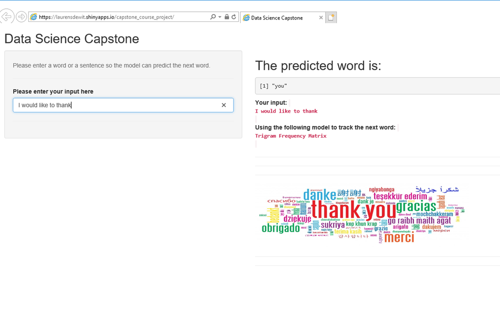

## Overview

- The goal of this presentation is to elaborate on what the application that was built does.
- Data were obtained from HC Corpora.
- After the data were obtained they were merged, cleaned, explored, visualized and tokenized. Once these steps were taken a prediction model was built.

## Methodology

- During cleaning, the text was converted to lower case, punctuation was removed, and numbers were removed.
- During tokenization, data was summarized into n-grams. Please see [this link](https://en.wikipedia.org/wiki/N-gram) for a good description of an N-gram.
- Once the N-grams were built they could be used as input for the model. I decided to go with unigrams, bigrams, trigrams, and quadrams.

## Description of Application

- The application predicts the next word in a piece of text (sentence) entered by the user.
- The word is obtained from an n-gram matrix. This matrix is either tokenized as unigram, bigam, trigram, or quadram.
- As the user decides to change his/her input, the field of the predicted word is changed dynamically.